# Tarea

Grupo 2

# EJERCICIOS PARTE 1

Cargar las variables almacenadas en el siguiente archivo [Rdata](https://goo.gl/uDzU8v)

### 1. Calcula los valores numéricos aproximados de:

1. $\frac{0.3 \cdot 0.15}{0.3 \cdot 0.15 + 0.2 \cdot 0.8 + 0.5 \cdot 0.12}$

```r
a<- (0.3*0.5)/(0.3*0.15+0.2*0.8+0.5*0.12)
a
```

```
## [1] 0.5660377
```

2. $\frac{5^6}{6!} e^{-5}$

```r
b<-(exp(-5)*5**6)/factorial(6)
b
```

```
## [1] 0.1462228
```

3. $\begin{pmatrix} 20 \\ 7 \end{pmatrix} 0.4^7 0.6^{13}$

```r
c<-choose(20,7)*(0.4**7)*(0.6**13)
c
```

```
## [1] 0.1658823
```

### 2. Realizar la siguiente suma

1. $1+2+3+...+1000$

```r
sum(1:1000)
```

```
## [1] 500500
```

2. $1+2+4+8+16+...+1024$

```r
sum(seq(2,1024,2))       #Creamos una secuencia cada "2" y sumamos
```

```
## [1] 262656
```

### 3. El vector `grupo` representa el grupo al que pertenece una serie de alumnos

1. ¿Cuántos elementos tiene?

```r
tibble(grupo) %>%            #Cantidad de datos
  count()
```

```
## # A tibble: 1 x 1
##       n
##   <int>
## 1   192
```

2. ¿En qué posiciones del vector está la letra “A”?

```r
tibble(grupo) %>%
  mutate(orden = 1:n(), grupo = grupo) %>% #Agregamos una columna de posicion
  filter(grupo == "A")                     #Filtramos solo "A"
```

```
## # A tibble: 14 x 2
##    grupo orden
##    <chr> <int>
##  1 A         2
##  2 A         8
##  3 A        17
##  4 A        21
##  5 A        28
##  6 A        84
##  7 A       101
##  8 A       108
##  9 A       111
## 10 A       115
## 11 A       123
## 12 A       136
## 13 A       190
## 14 A       192
```

### 4. El vector `nota` representa la nota de un examen de los alumnos que están en los grupos del vector `grupo`.

1. ¿Cuanto suman todas las notas?

```r
sum(nota)                            #Sumamos las notas
```

```
## [1] 962
```

2. ¿Cual es la media aritmética de todas las notas?

```r
median(nota)                         #Media de las notas
```

```
## [1] 5
```

3. ¿En qué posiciones están las notas mayores de *7.0*?

```r
tibble(nota) %>%
  mutate(orden = 1:n() , nota =nota) %>% #Agregamos una columna de posicion
  filter(nota>7)                         #Notas mayores de "7"
```

```
## # A tibble: 4 x 2
##    nota orden
##   <dbl> <int>
## 1   7.2    81
## 2   7.4   103
## 3   7.7   120
## 4   7.5   151
```

4. Visualiza las notas ordenadas de mayor a menor

```r
tibble(grupo,nota) %>%                   #Unimos "Grupo" y "Nota"
  arrange(nota) %>%                     #Ordenamos de mmenor a mayor NOTAS
  mutate(Orden = 1:n())                 #Agregamos posicion
```

```
## # A tibble: 192 x 3
##    grupo  nota Orden
##    <chr> <dbl> <int>
##  1 B       1.7     1
##  2 D       2.5     2
##  3 D       2.6     3
##  4 E       2.7     4
##  5 E       2.9     5
##  6 D       2.9     6
##  7 A       2.9     7
##  8 E       3       8
##  9 E       3.1     9
## 10 C       3.2    10
## # ... with 182 more rows
```

5. ¿En qué posición está la nota máxima?

```r
tibble(nota) %>%
  mutate(orden = 1:n() , nota =nota) %>%   #Agregamos posicion
  slice_max(nota)                         #Seleccionamos la maxima "Nota"
```

```
## # A tibble: 1 x 2
##    nota orden
##   <dbl> <int>
## 1   7.7   120
```

### 5. A partir de los vectores `grupo` y `nota` definidos.

1. Suma las notas de los 10 primeros alumnos del vector

```r
sum(nota[1:10])                             #Sumamos los primeros 10
```

```
## [1] 51.8
```

2. ¿Cuántos alumnos hay del grupo *C*?

```r
tibble(grupo) %>%
  filter(grupo == "C") %>%                 #Filtramos solo "C"
  count()                                  #Contamos
```

```
## # A tibble: 1 x 1
##       n
##   <int>
## 1    39
```

3. ¿Cuántos alumnos han aprobado?

```r
tibble(nota) %>%
  filter(nota >= 5.1) %>%                 #Filtramos solo "C"
  count()                                  #Contamos
```

```
## # A tibble: 1 x 1
##       n
##   <int>
## 1    93
```

4. ¿Cuántos alumnos del grupo *B* han aprobado?

```r
tibble(grupo, nota) %>%
  filter(nota >= 5.1 ,grupo == "B") %>%   #Filtramos Aprobado y solo "B"
  count()
```

```
## # A tibble: 1 x 1
##       n
##   <int>
## 1    10
```

5. ¿Qué porcentaje de alumnos del grupo *C* han aprobado?

```r
(tibble(grupo, nota) %>%
  filter(nota >= 5.1 ,grupo == "C") %>%   #Filtramos Aprobado y solo "B"
  count()/tibble(grupo) %>%
  filter(grupo == "C") %>%   #Filtramos solo "C"
  count())*100
```

```
##          n
## 1 56.41026
```

6. ¿De qué grupos son la máxima y mínima notas de toda la muestra?

```r
tibble(grupo,nota) %>%
  slice_max(nota)      #Maxima nota
```

```
## # A tibble: 1 x 2
##   grupo  nota
##   <chr> <dbl>
## 1 E       7.7
```

```r
tibble(grupo,nota) %>%
  slice_min(nota)      #Minima nota
```

```
## # A tibble: 1 x 2
##   grupo  nota
##   <chr> <dbl>
## 1 B       1.7
```

7. Nota media de los alumnos de grupo *A* y *B*, juntos, considerando sólo a los que han aprobado.

```r
tibble(grupo, nota) %>%
  filter(grupo == "A" & nota > 5|         #Grupo A y Aprobado
         grupo == "B" & nota > 5) %>%     #Grupo B y Aprobado
  summarise(mean(nota))                   #Media
```

```
## # A tibble: 1 x 1
##   `mean(nota)`
##          <dbl>
## 1         5.94
```

### 6. Calcula el percentil 66 de las notas de todos los alumnos, y también de los alumnos del grupo C.

```r
quantile(nota, c(0.66))    #Percentil 66
```

```
## 66%
## 5.5
```

```r
tibble(grupo, nota) %>%
  filter(grupo == "C") %>%       #Filtramos solo C
  summarise(quantile(nota, c(0.66)))  #Percentil 66
```

```
## # A tibble: 1 x 1
##   `quantile(nota, c(0.66))`
##                       <dbl>
## 1                      5.81
```

### 7. Un alumno tiene una nota de 4.9. ¿Qué porcentaje, del total de alumnos, tiene una nota menor o igual que la suya? ¿Y qué porcentaje tiene una nota mayor o igual que la suya?

```r
(tibble(nota) %>%
  filter(nota <= 4.9) %>%   #Filtramos Nota menor a 4.9
  count()/tibble(grupo) %>%
  count())*100
```

```
##        n
## 1 46.875
```

```r
(tibble(nota) %>%
  filter(nota >= 4.9) %>%   #Filtramos Nota mayor a 4.9
  count()/tibble(grupo) %>%
  count())*100
```

```
##       n
## 1 56.25
```

### 8. Realiza el gráfico de diagramas de caja de las notas de cada grupo, para poder comparar el nivel de cada uno de ellos.

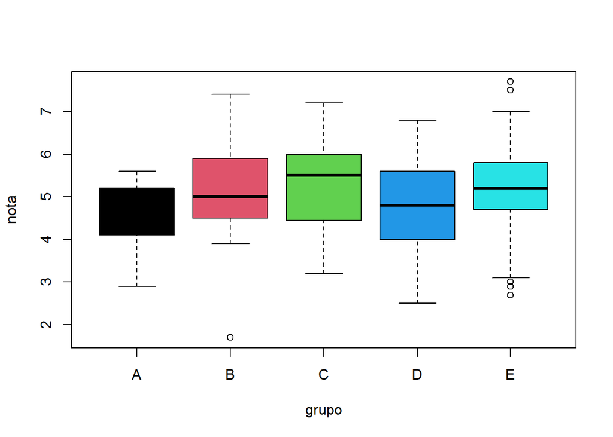

```r
df<- tibble(grupo,nota)
boxplot(`nota` ~ `grupo`,df, col = palette(rainbow(4)))
```

### 9. Si la variable `conc` recoge la concentración de plomo (en ppm) en el aire de cierta zona durante un día completo.

1. ¿Cuál ha sido la concentración máxima?

```r
tibble(conc) %>%
  slice_max(conc)
```

```
## # A tibble: 1 x 1
##    conc
##   <dbl>
## 1  47.3
```

2. ¿En cuántos de los muestreos se ha superado la concentración de 40.0 ppm?

```r
tibble(conc) %>%
  filter(conc > 40) %>%
  count()
```

```
## # A tibble: 1 x 1
##       n
##   <int>
## 1    61
```

3. ¿Cuál ha sido la concentración media del día?

```r
tibble(conc) %>%
  summarise(median(conc))
```

```
## # A tibble: 1 x 1
##   `median(conc)`
##            <dbl>
## 1           24.4
```

4. ¿Cuáles fueron las 10 mediciones más bajas del día?

```r
tibble(conc) %>%                   #Unimos "Grupo" y "Nota"
  arrange(conc)
```

```
## # A tibble: 288 x 1
##     conc
##    <dbl>
##  1  0.93
##  2  1.07
##  3  1.77
##  4  2.03
##  5  2.58
##  6  2.73
##  7  2.75
##  8  2.88
##  9  2.88
## 10  2.91
## # ... with 278 more rows
```

5. Si la primera medida fue a las 00:00. ¿A qué hora del día se alcanzó la concentración máxima?

```r
Hora<- seq(0,24-1/12,1/12)
length(Hora)
```

```
## [1] 288
```

```r
tibble(Hora,conc) %>%
  slice_max(conc)
```

```
## # A tibble: 1 x 2
##    Hora  conc
##   <dbl> <dbl>
## 1  11.8  47.3
```

```r
#seq(as.double())
#seq(as.POSIXct("2020-01-01 00:00"),as.POSIXct("2020-01-01 23:00"),by=" min")
#seq(as.POSIXct("2020-01-01 00:00"),as.POSIXct("2020-01-01 24:00"),by = "1/12 min")

#seq(as.POSIXct("2020-01-01 00:00"),as.POSIXct("2020-01-01 24:00"),by="1/12 min")
```

```r
length(conc)
```

```
## [1] 288
```

```r
tiempo_recojo <- 23/length(conc) #tiempo de recojo de cada concentracion
which(conc == max(conc)) #ocupacion dd la maxima concentracion
```

```
## [1] 142
```

```r
produc <- tiempo_recojo * which(conc == max(conc))
produc
```

```
## [1] 11.34028
```